# 原始資料重製分析及問卷中文化建置

2021-08-12

若要取得專案資料，可由[github倉庫](https://github.com/SCgeeker/LAB_metaprojects/tree/main/Projects/202107_CM)下載。

## 中文化問卷建置資訊

- Psytoolkit問卷資料測試
- [台灣事實查核中心COVID-19專區](https://tfc-taiwan.org.tw/topic/3826)
- [新興科技媒體中心COVID-19專區](https://smctw.tw/)

## 原始資料重製分析

- 認知動機問卷重製分析
- [第一波疫情資訊可信度重製分析]
- 第一波媒體使用問卷重製分析
- [第一波疫情資訊更新管道及頻率重製分析]
- [第二波疫情資訊可信度重製分析]
- [第二波疫情起源說法可信度重製分析]

### 下載原始資料映像檔

```r
## Download and load W1 rawdata from OSF
osf_retrieve_file("he2v7") %>%
  osf_download()
```

```
## # A tibble: 1 x 4
##   name                        id                       local_path       meta
##   <chr>                       <chr>                    <chr>            <list>
## 1 anonymous_raw_data_W1.Rdata 5f69eb869e9a3d01136e2cc9 ./anonymous_raw~ <named ~
```

```r
## Download and load W2 rawdata from OSF
osf_retrieve_file("ch68a") %>%
  osf_download()
```

```
## # A tibble: 1 x 4
##   name                     id                       local_path         meta
##   <chr>                    <chr>                    <chr>              <list>
## 1 data_W1_W2_recoded.Rdata 5f69ea689e9a3d01136e2926 ./data_W1_W2_reco~ <named l~
```

### 載入原始資料物件

```r
load(list.files(recursive = TRUE,full.names = TRUE,include.dirs = TRUE,pattern = "*.Rdata")[1])
load(list.files(recursive = TRUE,full.names = TRUE,include.dirs = TRUE,pattern = "*.Rdata")[2])
ls()
```

```
## [1] "auto_directory"     "data_factors"       "data_numeric"
## [4] "data_W1_W2_recoded" "dir"                "items"
## [7] "tag_info"
```

```r
file.remove(list.files(recursive = TRUE,full.names = TRUE,include.dirs = TRUE,pattern = "*.Rdata"))
```

```
## [1] TRUE TRUE
```

### Wave 1原始資料欄位說明清單

```r
items %>% rmarkdown::paged_table(options = list(rows.print = 20))
```

| key | value |
| --- | --- |
| StartDate | Start Date |
| EndDate | End Date |
| Duration..in.seconds. | Duration (in seconds) |
| ResponseId | Response ID |
| ID | Please enter your Prolific ID here: |
| Q1T_First.Click | Timing - First Click |
| Q1T_Last.Click | Timing - Last Click |
| Q1T_Page.Submit | Timing - Page Submit |
| Q1T_Click.Count | Timing - Click Count |
| Q1_1 | What is your current view on the following statements about the coronavirus? (Try to answer promptly based on your first instinct) - The first known case of the coronavirus was in Wuhan, China. |

[output cut: 144 more lines]

```
Q1: 第一波疫情資訊可信度評分 = Table 3
Q2~Q7: 參與者背景資訊調查
Q8~Q10: 媒體使用習慣調查 => Figure 2
Q12,Q14,Q15: 疫情資訊更新管道及頻率 => Table4, Figure 3, Table 5
Q16: Need for Cognition scale
Q17: Need for Cognitive Closure scale
```

### Wave 2 原始資料欄位說明清單

```r
tag_info %>% rmarkdown::paged_table(options = list(rows.print = 20))
```

| item_var_tag | info | category | wave |
| --- | --- | --- | --- |
| ID | Prolific ID number | NA | NA |
| W1_01 | The first known case of the coronavirus was in Wuhan, China. | True statement | 1 |
| W1_02 | The coronavirus is primarily spread through coughing and sneezing. | True statement | 1 |
| W1_03 | The coronavirus is especially deadly for older adults. | True statement | 1 |
| W1_04 | Fever is a potential symptom of the coronavirus. | True statement | 1 |
| W1_05 | The coronavirus can be spread by people who don't show the symptoms. | True statement | 1 |
| W1_06 | The coronavirus comes from animals. | True statement | 1 |
| W1_07 | There is no treatment yet for the coronavirus. | True statement | 1 |
| W1_08 | It might take 14 days after exposure to the coronavirus before you show symptoms. | True statement | 1 |
| W1_09 | Social distancing helps slow down the spread of the coronavirus. | True statement | 1 |

[output cut: 70 more lines]

```
W1_: 第一波疫情資訊可信度評分 => Table 7
W2_: 第二波疫情資訊可信度評分 => Table 7
Q1_: 疫情起源說法可信度重製分析
```

### Wave 1 正式分析資料

根據以下描述，篩選納入正式分析的資料：

“Five hundred and twenty-six respondents completed the Wave 1 survey via the Prolific.com platform. Sixteen respondents were excluded for spending too much time on the survey(”Duration..in.seconds." -> “Q1T_Page.Submit”). Another nine respondents were excluded for failing the catch question(“Q1_CATCH1”)."

由於初次嘗試發現分組人數與論文不一致，聯絡論文第一作者Arnout Boot，得知16位被排除的參與者是根據完成“Knowledge Test”的秒數。

```r
## check the equality of two data sets
sum(data_factors$Q1T_Page.Submit != data_numeric$Q1T_Page.Submit)
```

```
## [1] 0
```

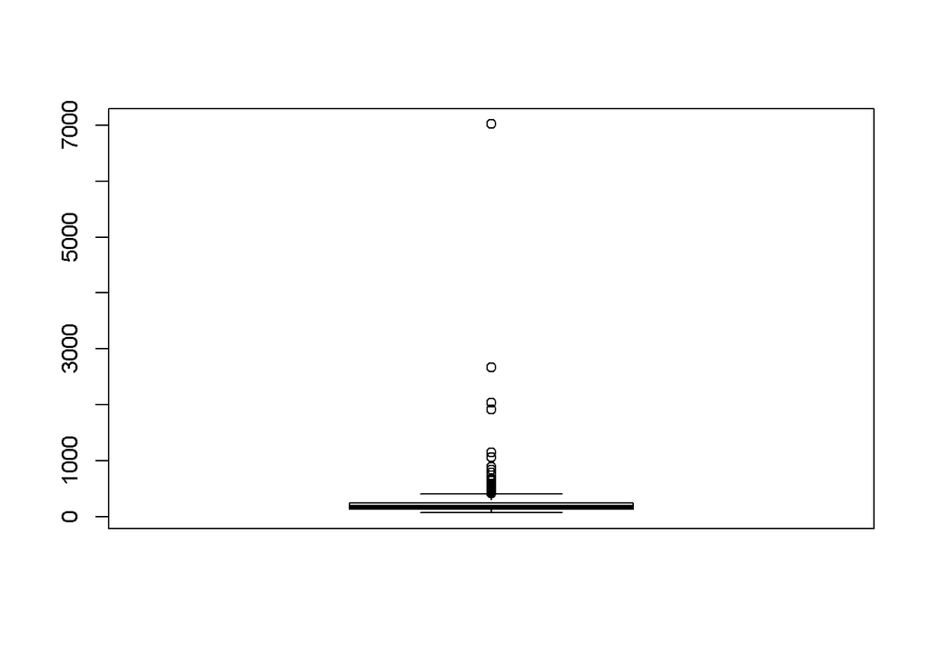

```r
## Boxplot for test duration
boxplot(data_numeric$Q1T_Page.Submit)
```

```r
wave1_rawdata <- data_numeric %>%
## exclude the participants who spent more than 999 seconds on the knowledge test
  filter(Q1T_Page.Submit < 999) %>%
## exclude the participants who failed the catch question
  filter(Q1_CATCH1 == 5) %>%
## ## exclude the participants who spent time on the knowledge test longer than 3.29 standardized time
  filter(scale(Q1T_Page.Submit)<3.29)
## How many participants' data are analyzed?
wave1_rawdata %>%
  summarise(N=n())
```

```
##     N
## 1 501
```

重製原始論文 Table 3描述統計(預備搬移到“第一波疫情資訊可信度重製分析”)

```r
## True statement "I am sure this is true"

## Approach 1, my favor
wave1_rawdata %>%
  select(ID,Q1_1:Q1_12) %>%
  pivot_longer(cols = starts_with("Q1_"), names_to = "True_statment", values_to = "rating") %>%
  group_by(ID) %>%
  summarise(True_Statement_5 = mean(rating == 5),
            True_Statement_4 = mean(rating == 4),
            True_Statement_3 = mean(rating == 3),
            True_Statement_2 = mean(rating == 2),
            True_Statement_1 = mean(rating == 1)) %>%
  pivot_longer(cols = starts_with("True_Statement_"), names_to = "Options",values_to = "Percentage") %>%
  group_by(Options) %>%
  summarise(Mean = round(mean(Percentage)*100,1),
            SD = round(sd(Percentage)*100,1),
            CI_L = round(Mean + qnorm(.025)*SD/sqrt(length(unique(ID))),1),
            CI_U = round(Mean + qnorm(.975)*SD/sqrt(length(unique(ID))),1),
            MIN = min(Percentage),
            MAX = max(Percentage)) %>%
  arrange(desc(Options))
```

```
## # A tibble: 5 x 7
##   Options           Mean    SD  CI_L  CI_U   MIN   MAX
##   <chr>            <dbl> <dbl> <dbl> <dbl> <dbl> <dbl>
## 1 True_Statement_5  56.1  22    54.2  58       0 1
## 2 True_Statement_4  29.4  19    27.7  31.1     0 1
## 3 True_Statement_3   8.2  10.3   7.3   9.1     0 0.833
## 4 True_Statement_2   4.4   6.1   3.9   4.9     0 0.333
## 5 True_Statement_1   1.9   4.1   1.5   2.3     0 0.25
```

```r
## Approach 2
wave1_rawdata %>%
  select(Q1_1:Q1_12) %>%
  summarise(Q1_1_5 = sum(Q1_1==5)/length(Q1_1),
            Q1_2_5 = sum(Q1_2==5)/length(Q1_2),
            Q1_3_5 = sum(Q1_3==5)/length(Q1_3),
            Q1_4_5 = sum(Q1_4==5)/length(Q1_4),
            Q1_5_5 = sum(Q1_5==5)/length(Q1_5),
            Q1_6_5 = sum(Q1_6==5)/length(Q1_6),
            Q1_7_5 = sum(Q1_7==5)/length(Q1_7),
            Q1_8_5 = sum(Q1_8==5)/length(Q1_8),
            Q1_9_5 = sum(Q1_9==5)/length(Q1_9),
            Q1_10_5 = sum(Q1_10==5)/length(Q1_10),
            Q1_11_5 = sum(Q1_11==5)/length(Q1_11),
            Q1_12_5 = sum(Q1_12==5)/length(Q1_12)) %>%
  pivot_longer(cols = starts_with("Q1_"),names_to = "True_Statement_5", values_to = "Percentage") %>%
  summarise(Average = round(mean(Percentage)*100,1),
            SD = round(sd(Percentage)*100),1)
```

```
## # A tibble: 1 x 3
##   Average    SD   `1`
##     <dbl> <dbl> <dbl>
## 1    56.1    25     1
```

### 媒體使用問卷

```r
data.frame(TEXT = wave1_rawdata$Q10_1, CODE = wave1_rawdata$Q10_1) %>% distinct() %>% arrange(CODE)
```

```
##   TEXT CODE
## 1   38   38
## 2   39   39
## 3   40   40
## 4   41   41
## 5   42   42
```

```r
data.frame(TEXT = wave1_rawdata$Q10_2, CODE = wave1_rawdata$Q10_2) %>% distinct() %>% arrange(CODE)
```

```
##   TEXT CODE
## 1   38   38
## 2   39   39
## 3   40   40
## 4   41   41
## 5   42   42
```

### Boot et al.(2021)確證性假設

[第一波預先註冊](https://osf.io/rst9m/)

[第二波預先註冊](https://osf.io/mp2ua/)

H1a: 高NC者對疫情的正確認識高於低NC者  
H1b: 高NC者更新疫情資訊的頻率高於低NC者  
H1c: 高NC者對疫情資訊來源正確性的要求高於低NC者  
H2: 高NCC者比低NCC者認為是真實的資訊更有信心  
H3: 低認知動機者(低NC,低NCC)容易接受陰謀論說法

### Boot et al.(2021)分析結果重點

- 第一波2020/3/27執行、篩選後參與者501人; 第二波2020/7/1執行、第一波回鍋參與者326人
- H1a: 迴歸分析確認高NC者掌握資訊的正確度高於低NC者
- H1b: 迴歸分析無法支持高NC者更新疫情資訊的頻率高於低NC者
- H1c: 集群分析無法支持高NC者對疫情資訊來源正確性的要求高於低NC者
- H2: 描述統計顯示高NCC者比低NCC者認為是真實的資訊更有信心( https://osf.io/8jfwe/ Table 9,10 回答“I am sure this is ture”/“I am sure this is not true”的分組信賴區間)；迴歸分析並未充分支持。
- H3: 迴歸分析無法支持低認知動機者(低NC,低NCC)容易接受陰謀論說法
- 第一波與第二波消息可信度比較
  - Table 7 缺乏證據的消息認為可信的比例增加，有統計顯著性的差異
  - “新冠肺炎病毒是人造的”第一波調查超過一半認為絕對可信(Figure 1)，第二波調查絕對可信比例降低，超過一半仍然認為可信([Appendix B](https://osf.io/nr6bw/), Figure 2)
  - 第二波調查訊息來源的重視程度([Appendix B](https://osf.io/nr6bw/), Figure 5)最重視WHO與國家衛生機構發佈的資訊，親近者與康復者提供的資訊也有一定的重視程度，政治人物言論最不被重視